English Français

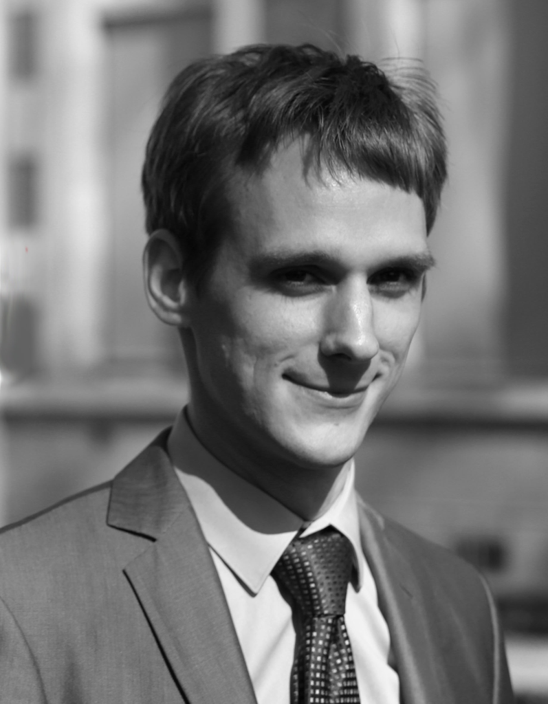

# Étienne POUGET

etienne.pouget@outlook.com [LinkedIn](https://www.linkedin.com/in/etienne-pouget) [GitHub](https://github.com/Vifespoir) [Website](https://etiennepouget.com/)  
Autodidacta y capaz de aprender rápidamente buscando una oportunidad en Barcelona.

## Experiencia Laboral

### [3scale - Barcelona](https://3scale.net/) Diciembre 2014 - Junio 2016

**Ventas & Eventos:** Generación de clientes potenciales, seguimiento de estos a través de correos electrónicos, ventas y eventos en vivo incluyendo la demostración del producto y prueba de concepto.

**Creación de contenidos:** Creación de materiales de ventas y informes de mercadotecnia orientada. Publicando un subconjunto de resultados en forma de serie de artículos web (cf. Publicaciones). Haciendo campañas de promoción por correo electrónico dirigido al sector financiero con [Marketo](https://www.marketo.com/).

**Enriquecimiento de Datos:** Correlación de información de clientes encontrados por web scrapping con base de datos interna para mejorar nuestro entendimiento y las necesidades de nuestros clientes. Las herramientas informaticas usadas son: [Kimonolabs](https://www.kimonolabs.com/), [Import.io](https://www.import.io/) y el [Web-scraper](http://webscraper.io/)de Chrome.

**Análisis de datos:** Depuración y limpieza de datos financieros con mi propio algoritmo Python. Exposición de esos datos a través de SQL, ejecutando uniones, funciones de agregación y de tablas dinámicas (pivot). Creación de vistas y establecimiento de filtros de fechas y de categorías con [PeriscopeData](https://www.periscopedata.com/), una herramienta web de visualización.

### [Nanocloud - Paris](https://www.nanocloud.com) Augusto 2013 - Noviembre 2013

**Estrategia:** Redacción de planes estratégicos para Nanocloud que permitie valorar una empresa €7 millones.

### [WHV - Nueva Zelanda](https://www.immigration.govt.nz/new-zealand-visas/options/work/thinking-about-coming-to-new-zealand-to-work/working-holiday-visa) Augusto 2011 - Abril 2012

**Trabajos variados:** Camarero en Wellington, trabajo en campos orgánicos con la ONG [WWOOF](http://www.wwoof.net/).

### [LGBC - Versailles, Francia](http://www.lgbc.uvsq.fr/laboratoire-de-genetique-et-biologie-cellulaire-lgbc-/langue-en/) Junio 2010 - Julio 2010

**Investigación:** Mejora gradual de un proceso experimental sobre el ADN de las moscas de la fruta.

## Formación

### [NEOMA Business School, Reims, Francia](http://www.neoma-bs.com/en/) 2012 - 2015

**Master’s:** Administración de negocio, gestión y estrategia empresarial con honores.

### [UVSQ, Versailles, Francia](http://welcome.uvsq.fr/) 2008 - 2011

**Licenciatura:** Genética, Biología celular y Bioquímica.

## Proyectos

**[Assistente de Machine Learning](https://mlearning.etiennepouget.com) :** Programación de una aplicación para ayudar a la elección de un algoritmo. Producción de gráficos desde datos limpios. Hoja de ruta: documentación, limpieza y preparación de datos, ejecución del algoritmo de machine learning. Alojamiento web propio (VPS), usando un reverse proxy (NGINX), HTML y CSS.

**[Blog Personal:](https://etiennepouget.com)** Modificación de [Pelican](http://blog.getpelican.com/) para ajustar imágenes al carrusel [Bootstrap CSS](http://getbootstrap.com/). Personalización del Diseño.

**[Generador de nombres:](https://name-generator.etiennepouget.com)** Web-app que genera nombres correspondientes a un rango de edad basado por estadísticas.

## Publicaciones

[Streaming APIs Are Paving The Way For Real-time, Agile Banking; December 16, 2015](https://www.3scale.net/2015/12/streaming-apis-are-paving-the-way-for-real-time-agile-banking/)  
[Developers Will be the Cornerstone of the Banking APIs Revolution; September 25, 2015](https://www.3scale.net/2015/09/developers-will-be-the-cornerstone-of-the-banking-apis-revolution/)  
[Financial Institutions are Embracing APIs; September 15, 2015](https://www.3scale.net/2015/09/financial-institutions-are-embracing-apis-psd2/)  
[European Banking Authority Opens a New Era of Open Banking; September 8, 2015](https://www.3scale.net/2015/09/european-banking-authority-new-era-of-open-banking/)

#### Talentos y especializaciones

| **Idiomas** | Nativo | Bilingüe | Avanzado |
| --- | --- | --- | --- |
| **Estrategia** | Métrica de Marketing | Estrategia híbrida | Desarrollo de negocio |
| **Informática** | Office Suite | Python, SQL | APIs, SaaS |
| **Biología** | Biología celular | Genética | Biotecnología |

#### Intereses

| **Voluntariado** | Líder de campamento | WWOOF NZ | NEOMA ALUMNI, todavía |
| --- | --- | --- | --- |
| **Experiencia en extranjero** | EE.UU. | Corea del Sur, Taiwán | Nueva Zelanda |
| **Viajes** | Irán | China, Mongolia | Europa del este, Ucrania |
| **Aficiones** | Ciclismo, Senderismo | Hacer vela | Origami |